# IODS course project

For linear discriminant analysis we need to scale the data. This means subtracting the column means from the corresponding colums and divide the difference with standard deviation. This is easily managed with the `scale()`-function.

```r
boston_scaled <- scale(Boston)
```

Let’s look at the summariers of the scaled variables:

```r
summary(boston_scaled)
```

```
##       crim                 zn               indus
##  Min.   :-0.419367   Min.   :-0.48724   Min.   :-1.5563
##  1st Qu.:-0.410563   1st Qu.:-0.48724   1st Qu.:-0.8668
##  Median :-0.390280   Median :-0.48724   Median :-0.2109
##  Mean   : 0.000000   Mean   : 0.00000   Mean   : 0.0000
##  3rd Qu.: 0.007389   3rd Qu.: 0.04872   3rd Qu.: 1.0150
##  Max.   : 9.924110   Max.   : 3.80047   Max.   : 2.4202
##       chas              nox                rm               age
##  Min.   :-0.2723   Min.   :-1.4644   Min.   :-3.8764   Min.   :-2.3331
##  1st Qu.:-0.2723   1st Qu.:-0.9121   1st Qu.:-0.5681   1st Qu.:-0.8366
##  Median :-0.2723   Median :-0.1441   Median :-0.1084   Median : 0.3171
##  Mean   : 0.0000   Mean   : 0.0000   Mean   : 0.0000   Mean   : 0.0000
##  3rd Qu.:-0.2723   3rd Qu.: 0.5981   3rd Qu.: 0.4823   3rd Qu.: 0.9059
##  Max.   : 3.6648   Max.   : 2.7296   Max.   : 3.5515   Max.   : 1.1164
##       dis               rad               tax             ptratio
##  Min.   :-1.2658   Min.   :-0.9819   Min.   :-1.3127   Min.   :-2.7047
##  1st Qu.:-0.8049   1st Qu.:-0.6373   1st Qu.:-0.7668   1st Qu.:-0.4876
##  Median :-0.2790   Median :-0.5225   Median :-0.4642   Median : 0.2746
##  Mean   : 0.0000   Mean   : 0.0000   Mean   : 0.0000   Mean   : 0.0000
##  3rd Qu.: 0.6617   3rd Qu.: 1.6596   3rd Qu.: 1.5294   3rd Qu.: 0.8058
##  Max.   : 3.9566   Max.   : 1.6596   Max.   : 1.7964   Max.   : 1.6372
##      black             lstat              medv
##  Min.   :-3.9033   Min.   :-1.5296   Min.   :-1.9063
##  1st Qu.: 0.2049   1st Qu.:-0.7986   1st Qu.:-0.5989
##  Median : 0.3808   Median :-0.1811   Median :-0.1449
##  Mean   : 0.0000   Mean   : 0.0000   Mean   : 0.0000
##  3rd Qu.: 0.4332   3rd Qu.: 0.6024   3rd Qu.: 0.2683
##  Max.   : 0.4406   Max.   : 3.5453   Max.   : 2.9865
```

At first glance the most noticable difference is that all the variables have zero mean. Also all the variables go from negative to positive. The normalization of the data makes it so that comparing the variables with each other is much easier since the range of the values in the raw data could vary widely. The values are quite similar across the board now. The the potential change in the values within a variable should now be proportionately same within each variable.

We also want the data to be a data frame:

```r
boston_scaled <- as.data.frame(boston_scaled)
```

Now we create a categorical variable of the crime rate in the Boston dataset using the quantiles as break points:

```r
bins <- quantile(boston_scaled$crim)
crime <- cut(boston_scaled$crim, breaks = bins, include.lowest = TRUE, labels = c("low", "med_low", "med_high", "high"))
boston_scaled <- dplyr::select(boston_scaled, -crim)
boston_scaled <- data.frame(boston_scaled, crime)
```

And divide the datasset to train and test sets so that 80% of the data belongs to the train set:

```r
n <- nrow(boston_scaled)
ind <- sample(n, size = n * 0.8)
train <- boston_scaled[ind,]
test <- boston_scaled[-ind,]
```

Save from test data and drop the crime variable from test data:

```r
correct_classes <- test$crime
test <- dplyr::select(test, -crime)
```

This is done because it is important when using a statistical method to predict something to have data to test how well the predictions fit.

Fit the linear discriminant analysis on the train set and print it. We use the categorical crime rate as the target variable and all the other variables as predictors:

```r
lda.fit <- lda(crime ~ ., data = train)
lda.fit
```

```
## Call:
## lda(crime ~ ., data = train)
##
## Prior probabilities of groups:
##       low   med_low  med_high      high
## 0.2425743 0.2450495 0.2599010 0.2524752
##
## Group means:
##                  zn      indus        chas        nox          rm
## low       1.0276790 -0.8945876 -0.11163110 -0.8833220  0.41451190
## med_low  -0.1063266 -0.2885723 -0.03371693 -0.5796700 -0.09846022
## med_high -0.3876019  0.1885343  0.21512144  0.4200668  0.02251974
## high     -0.4872402  1.0171096 -0.11793298  1.0538584 -0.40191062
##                 age        dis        rad        tax     ptratio
## low      -0.8991701  0.8864357 -0.6947544 -0.7181995 -0.49085598
## med_low  -0.3854024  0.3712842 -0.5491659 -0.4696072 -0.07137524
## med_high  0.4033777 -0.3811264 -0.4349821 -0.3223199 -0.28695774
## high      0.8173493 -0.8632636  1.6382099  1.5141140  0.78087177
##                black       lstat         medv
## low       0.37860892 -0.73848593  0.507241499
## med_low   0.31658776 -0.16793370  0.008184585
## med_high  0.08084392  0.04686293  0.126908825
## high     -0.78523963  0.91990436 -0.739838854
##
## Coefficients of linear discriminants:
##                  LD1         LD2         LD3
## zn       0.092803696  0.78937057 -1.05389479
## indus    0.058380656 -0.18169750  0.28732932
## chas    -0.033303999 -0.04495618  0.02604864
## nox      0.356626606 -0.75427270 -1.33323649
## rm       0.016175361 -0.05174669 -0.05437785
## age      0.233487691 -0.33951777 -0.12725798
## dis     -0.078487201 -0.32243666  0.26158232
## rad      3.387656397  0.93142368 -0.08138651
## tax      0.001682572 -0.04055726  0.59962809
## ptratio  0.131273170 -0.03802694 -0.30567656
## black   -0.092894573  0.02917679  0.07167844
## lstat    0.181566812 -0.25803873  0.34678385
## medv     0.089905710 -0.51358986 -0.15872972
##
## Proportion of trace:
##    LD1    LD2    LD3
## 0.9502 0.0381 0.0117
```

Then we provide a function for the lda biplot arrows, target classes as numeric and plot the ld results:

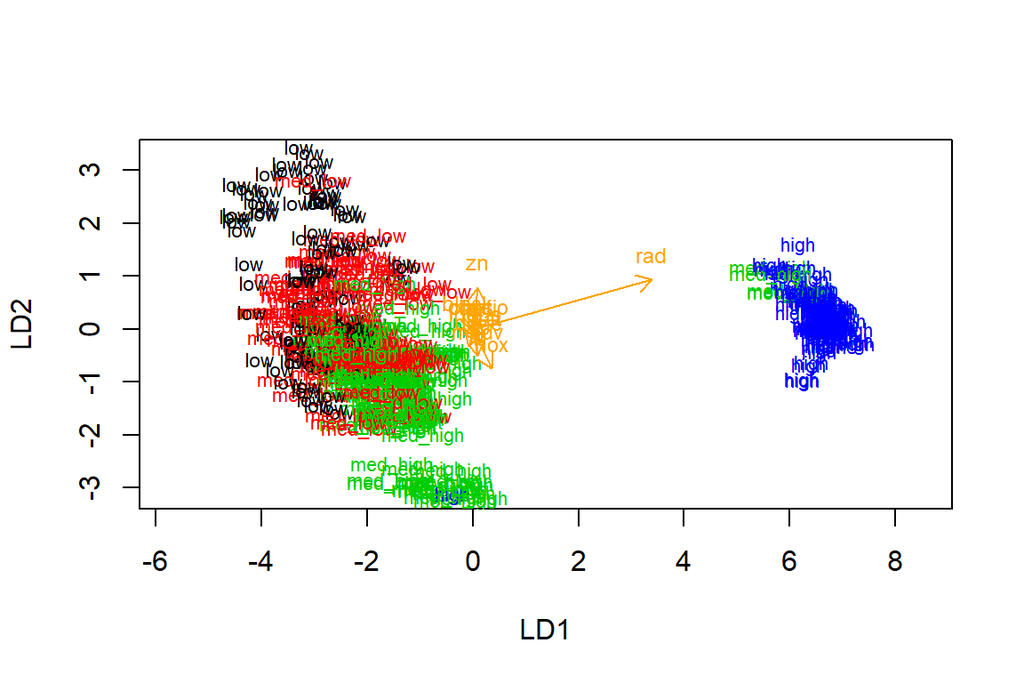

```r
lda.arrows <- function(x, myscale = 1, arrow_heads = 0.1, color = "orange", tex = 0.75, choices = c(1,2)){
  heads <- coef(x)
  arrows(x0 = 0, y0 = 0,
         x1 = myscale * heads[,choices[1]],
         y1 = myscale * heads[,choices[2]], col=color, length = arrow_heads)
  text(myscale * heads[,choices], labels = row.names(heads),
       cex = tex, col=color, pos=3)
}

classes <- as.numeric(train$crime)

plot(lda.fit, dimen = 2, col = classes, pch = classes)
lda.arrows(lda.fit, myscale = 1)
```

In the exercise it was asked to save and drop the crime variable but it was already done earlier. So either I donât understand something or thereâs a mistake in the assignment.